# chapter9 - Association Rules

alfonso

May 2, 2016

# 关联规则基础

关联规则是用来表示项集之间的**关联**或者**相关**的规则。一个关联规则有以下形式： $A\Rightarrow B$ 其中 $A,B$ 是不相交的项集。 有3种应用最广泛的用来选择规则的度量。  
1. support: the percentage of cases in the data that contains both $A$ and $B$  
2. confidence: the percentage of cases containing $A$ that also contain $B$  
3. lift: the ratio of confidence to the percentage of cases containing $B$

3者的计算公式如下： $support(A\Rightarrow B) = P(A\cap B) \\ confidence(A\Rightarrow B) = P(B|A) = \frac{P(AB)}{P(A)} \\ lift(A\Rightarrow B) = \frac{confidence(A\Rightarrow B)}{P(B)} = \frac{P(AB)}{P(A)P(B)}$

# 构建泰坦尼克数据集

`Titanic` 是一个4维的数据，我们需重建原数据，使得没一行表示一个人

```r
str(Titanic)
```

```
##  table [1:4, 1:2, 1:2, 1:2] 0 0 35 0 0 0 17 0 118 154 ...
##  - attr(*, "dimnames")=List of 4
##   ..$ Class   : chr [1:4] "1st" "2nd" "3rd" "Crew"
##   ..$ Sex     : chr [1:2] "Male" "Female"
##   ..$ Age     : chr [1:2] "Child" "Adult"
##   ..$ Survived: chr [1:2] "No" "Yes"
```

```r
sum(Titanic)
```

```
## [1] 2201
```

```r
df <- as.data.frame(Titanic)
head(df)
```

```
##   Class    Sex   Age Survived Freq
## 1   1st   Male Child       No    0
## 2   2nd   Male Child       No    0
## 3   3rd   Male Child       No   35
## 4  Crew   Male Child       No    0
## 5   1st Female Child       No    0
## 6   2nd Female Child       No    0
```

```r
titanic.raw <- NULL
for(i in 1:4){
  titanic.raw <- cbind(titanic.raw, rep(as.character(df[,i]), df$Freq))
}
titanic.raw <- as.data.frame(titanic.raw)
names(titanic.raw) <- names(df)[-5]
dim(titanic.raw)
```

```
## [1] 2201    4
```

```r
head(titanic.raw)
```

```
##   Class  Sex   Age Survived
## 1   3rd Male Child       No
## 2   3rd Male Child       No
## 3   3rd Male Child       No
## 4   3rd Male Child       No
## 5   3rd Male Child       No
## 6   3rd Male Child       No
```

```r
summary(titanic.raw)
```

```
##   Class         Sex          Age       Survived
##  1st :325   Female: 470   Adult:2092   No :1490
##  2nd :285   Male  :1731   Child: 109   Yes: 711
##  3rd :706
##  Crew:885
```

# 关联规则挖掘

一个经典的关联规则挖掘算法是 APRIORI，它是一个逐层、广度优先算法，计数频繁出现的项集，然后从中找出关联规则

```r
library(arules)
rules.all <- apriori(titanic.raw)
```

```
## Apriori
##
## Parameter specification:
##  confidence minval smax arem  aval originalSupport support minlen maxlen
##         0.8    0.1    1 none FALSE            TRUE     0.1      1     10
##  target   ext
##   rules FALSE
##
## Algorithmic control:
##  filter tree heap memopt load sort verbose
##     0.1 TRUE TRUE  FALSE TRUE    2    TRUE
##
## Absolute minimum support count: 220
##
## set item appearances ...[0 item(s)] done [0.00s].
## set transactions ...[10 item(s), 2201 transaction(s)] done [0.00s].
## sorting and recoding items ... [9 item(s)] done [0.00s].
## creating transaction tree ... done [0.00s].
## checking subsets of size 1 2 3 4 done [0.00s].
## writing ... [27 rule(s)] done [0.00s].
## creating S4 object  ... done [0.00s].
```

```r
quality(rules.all) <- round(quality(rules.all), digits=3)
inspect(rules.all)
```

```
##    lhs                                   rhs           support confidence
## 1  {}                                 => {Age=Adult}   0.950   0.950
## 2  {Class=2nd}                        => {Age=Adult}   0.119   0.916
## 3  {Class=1st}                        => {Age=Adult}   0.145   0.982
## 4  {Sex=Female}                       => {Age=Adult}   0.193   0.904
## 5  {Class=3rd}                        => {Age=Adult}   0.285   0.888
## 6  {Survived=Yes}                     => {Age=Adult}   0.297   0.920
## 7  {Class=Crew}                       => {Sex=Male}    0.392   0.974
## 8  {Class=Crew}                       => {Age=Adult}   0.402   1.000
## 9  {Survived=No}                      => {Sex=Male}    0.620   0.915
## 10 {Survived=No}                      => {Age=Adult}   0.653   0.965
## 11 {Sex=Male}                         => {Age=Adult}   0.757   0.963
## 12 {Sex=Female,Survived=Yes}          => {Age=Adult}   0.144   0.919
## 13 {Class=3rd,Sex=Male}               => {Survived=No} 0.192   0.827
## 14 {Class=3rd,Survived=No}            => {Age=Adult}   0.216   0.902
```

[output cut: 41 more lines]

```r
rules <- apriori(titanic.raw, control = list(verbose = F),
                 parameter = list(minlen = 2, supp = 0.005, conf = 0.8),
                 appearance = list(rhs = c("Survived=No", "Survived=Yes"), default = "lhs"))
quality(rules) <- round(quality(rules), digits=3)
rules.sorted <- sort(rules, by="lift")
inspect(rules.sorted)
```

```
##    lhs                                  rhs            support confidence
## 1  {Class=2nd,Age=Child}             => {Survived=Yes} 0.011   1.000
## 7  {Class=2nd,Sex=Female,Age=Child}  => {Survived=Yes} 0.006   1.000
## 4  {Class=1st,Sex=Female}            => {Survived=Yes} 0.064   0.972
## 10 {Class=1st,Sex=Female,Age=Adult}  => {Survived=Yes} 0.064   0.972
## 2  {Class=2nd,Sex=Female}            => {Survived=Yes} 0.042   0.877
## 5  {Class=Crew,Sex=Female}           => {Survived=Yes} 0.009   0.870
## 11 {Class=Crew,Sex=Female,Age=Adult} => {Survived=Yes} 0.009   0.870
## 8  {Class=2nd,Sex=Female,Age=Adult}  => {Survived=Yes} 0.036   0.860
## 9  {Class=2nd,Sex=Male,Age=Adult}    => {Survived=No}  0.070   0.917
## 3  {Class=2nd,Sex=Male}              => {Survived=No}  0.070   0.860
## 12 {Class=3rd,Sex=Male,Age=Adult}    => {Survived=No}  0.176   0.838
## 6  {Class=3rd,Sex=Male}              => {Survived=No}  0.192   0.827
##    lift
## 1  3.096
## 7  3.096
## 4  3.010
## 10 3.010
## 2  2.716
## 5  2.692
## 11 2.692
## 8  2.663
## 9  1.354
## 3  1.271
## 12 1.237
## 6  1.222
```

`supp` 设为0.005，则表示每个规则至少出现了12（`=ceiling(0.005 * 2201`）次。

# 移除冗余

上例中的 `rules.sorted` 中，rule1 涵盖了 rule2（成为 super），rule1 已经告诉我们所有存活下来的儿童。再有4，7，8相对于3，6，5是冗余的。我们使用以下代码来去掉冗余的规则。

```r
subset.matrix <- is.subset(rules.sorted, rules.sorted)
subset.matrix[lower.tri(subset.matrix, diag = T)] <- NA
#inspect(subset.matrix)
redundant <- colSums(subset.matrix, na.rm = T) >= 1
which(redundant)
```

```
##  {Class=2nd,Sex=Female,Age=Child,Survived=Yes}
##                                              2
##  {Class=1st,Sex=Female,Age=Adult,Survived=Yes}
##                                              4
## {Class=Crew,Sex=Female,Age=Adult,Survived=Yes}
##                                              7
##  {Class=2nd,Sex=Female,Age=Adult,Survived=Yes}
##                                              8
```

```r
rules.pruned <- rules.sorted[!redundant]
inspect(rules.pruned)
```

```
##    lhs                               rhs            support confidence
## 1  {Class=2nd,Age=Child}          => {Survived=Yes} 0.011   1.000
## 4  {Class=1st,Sex=Female}         => {Survived=Yes} 0.064   0.972
## 2  {Class=2nd,Sex=Female}         => {Survived=Yes} 0.042   0.877
## 5  {Class=Crew,Sex=Female}        => {Survived=Yes} 0.009   0.870
## 9  {Class=2nd,Sex=Male,Age=Adult} => {Survived=No}  0.070   0.917
## 3  {Class=2nd,Sex=Male}           => {Survived=No}  0.070   0.860
## 12 {Class=3rd,Sex=Male,Age=Adult} => {Survived=No}  0.176   0.838
## 6  {Class=3rd,Sex=Male}           => {Survived=No}  0.192   0.827
##    lift
## 1  3.096
## 4  3.010
## 2  2.716
## 5  2.692
## 9  1.354
## 3  1.271
## 12 1.237
## 6  1.222
```

# 理解规则

在 `rules.pruned` 列表中的第一条规则： `{Class=2nd,Age=Child} => {Survived=Yes}` 仅仅表示 `class 2nd` 的儿童都存活了，但并不能说明 `class 2nd` 的儿童比其它 `class` 的儿童有更高的存活率。为了进行验证我们使用如下代码：

```r
rules2 <- apriori(titanic.raw,
                 parameter = list(minlen = 3, supp = 0.002, conf = 0.2),
                 appearance = list(rhs = c("Survived=Yes"),
                                   lhs = c("Class=1st", "Class=2nd", "Class=3rd", "Age=Child", "Age=Adult"),
                                   default = "none"))
```

```
## Apriori
##
## Parameter specification:
##  confidence minval smax arem  aval originalSupport support minlen maxlen
##         0.2    0.1    1 none FALSE            TRUE   0.002      3     10
##  target   ext
##   rules FALSE
##
## Algorithmic control:
##  filter tree heap memopt load sort verbose
##     0.1 TRUE TRUE  FALSE TRUE    2    TRUE
##
## Absolute minimum support count: 4
##
## set item appearances ...[6 item(s)] done [0.00s].
## set transactions ...[6 item(s), 2201 transaction(s)] done [0.00s].
## sorting and recoding items ... [6 item(s)] done [0.00s].
## creating transaction tree ... done [0.00s].
## checking subsets of size 1 2 3 done [0.00s].
## writing ... [6 rule(s)] done [0.00s].
## creating S4 object  ... done [0.00s].
```

```r
rules.sorted2 <- sort(rules2, by="confidence")
inspect(rules.sorted2)
```

```
##   lhs                      rhs            support     confidence lift
## 1 {Class=2nd,Age=Child} => {Survived=Yes} 0.010904134 1.0000000  3.0956399
## 2 {Class=1st,Age=Child} => {Survived=Yes} 0.002726034 1.0000000  3.0956399
## 5 {Class=1st,Age=Adult} => {Survived=Yes} 0.089504771 0.6175549  1.9117275
## 4 {Class=2nd,Age=Adult} => {Survived=Yes} 0.042707860 0.3601533  1.1149048
## 3 {Class=3rd,Age=Child} => {Survived=Yes} 0.012267151 0.3417722  1.0580035
## 6 {Class=3rd,Age=Adult} => {Survived=Yes} 0.068605179 0.2408293  0.7455209
```

以上结果表明 `class 1st` 和 `class 2nd` 有相同的存活率。之所以 `class 1st` 没有出现在一次结果中，是因为被 `supp` 给限制了。

# 可视化关联规则

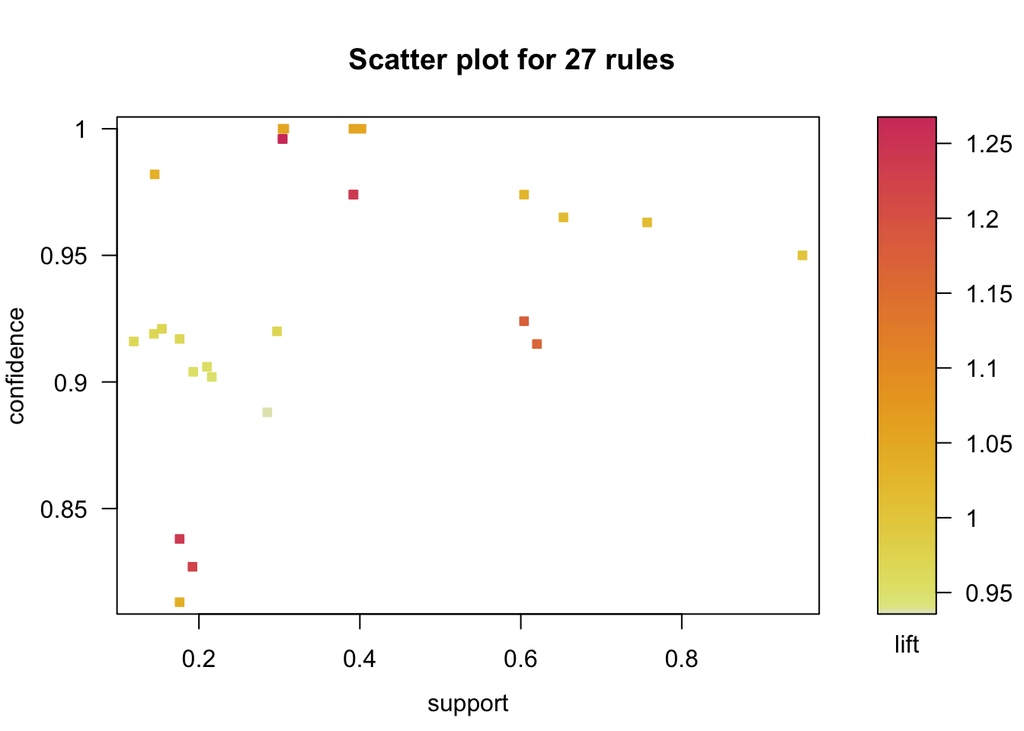

```r
library(arulesViz)
plot(rules.all)
```

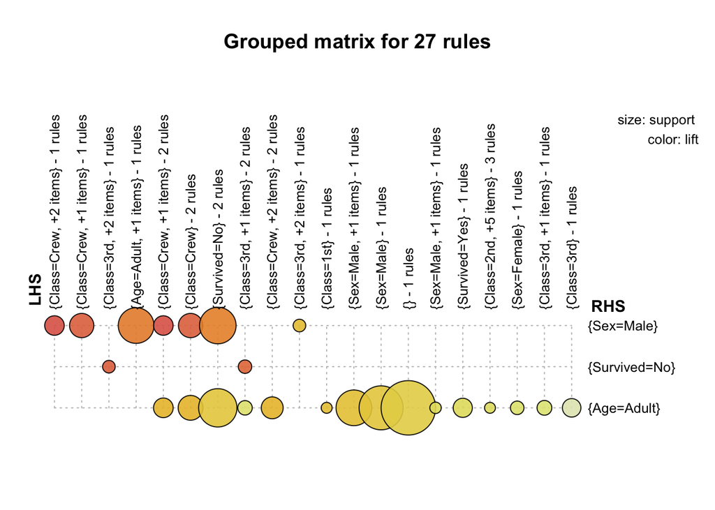

```r
plot(rules.all, method="grouped")
```

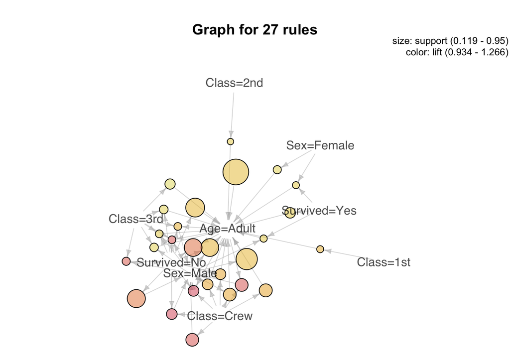

```r
plot(rules.all, method="graph")
```

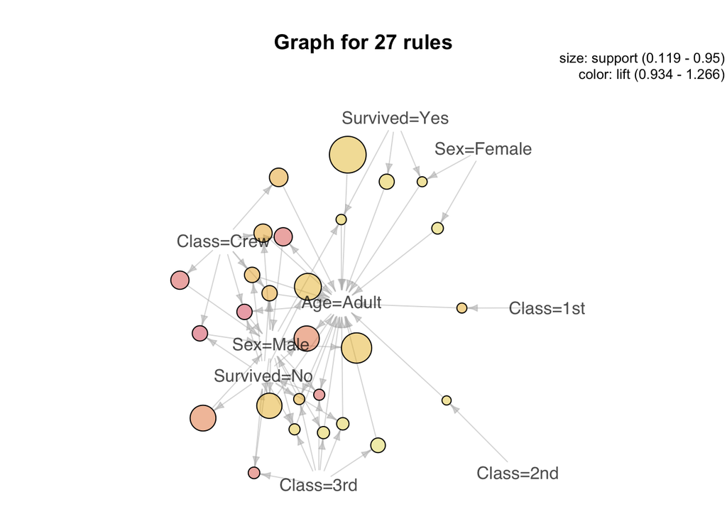

```r
plot(rules.all, method="graph", control=list(type="items"))
```

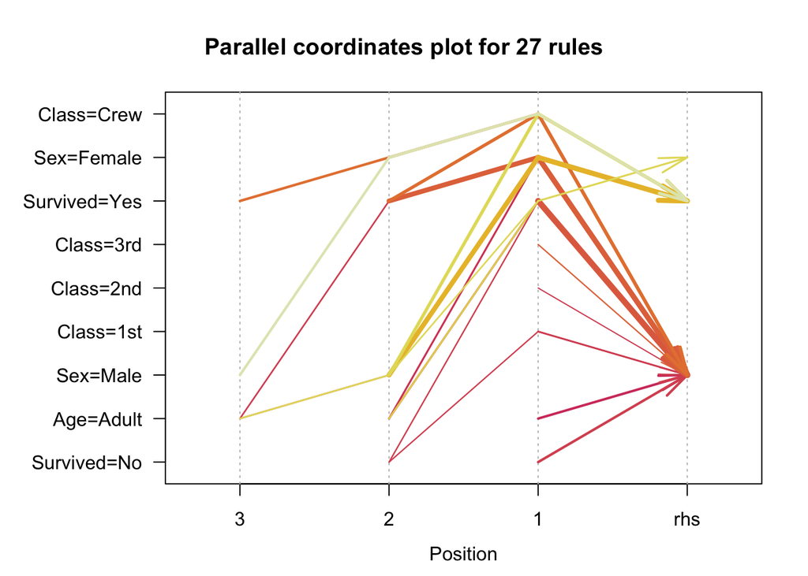

```r
plot(rules.all, method="paracoord", control=list(reorder=TRUE))
```